# Tarea 6: regularización ridge

En este ejemplo trabajaremos con un [ejemplo de Kaggle](https://www.kaggle.com/c/house-prices-advanced-regression-techniques), en donde queremos predecir el precio listado de una casa dependiendo de varias características.

El diccionario de datos está en el archivo *data_description.txt*

```r
library(tidyverse)
library(glmnet)
datos <- read_csv("./tarea_6_datos/data_train.csv", na= "") %>%
    select(-GarageYrBlt, -LotFrontage, -MasVnrArea, -GarageYrBlt, -MoSold, -PoolQC)
datos$MSSubClass <- factor(datos$MSSubClass)
```

### Preprocesamiento

Necesitamos hacer varios pasos de limpieza y preprocesamiento de datos. Aquí solo haremos una limpieza y transformación parcial para propósitos de nuestro ejemplo.

En primer lugar, nota que muchas de estas variables son categóricas. En los casos donde hay datos no disponibles (NA), estas se cuentan como una categoría más, por ejemplo:

```r
table(datos$Alley)
```

```
Grvl   NA Pave
  50 1369   41
```

En este caso, la categoría NA indica que la casa no tiene acceso por callejón. Igual que en el ejemplo del Titanic, convertimos estas variables con *dummy coding*, o *one hot encoding*.

Podemos usar la función *model.matrix* para hacer este preprocesamiento:

```r
x_datos <- model.matrix(SalePrice ~ ., datos %>% select(-Id))
x_datos <- x_datos[, -1] # quitamos columna de unos
y <- datos$SalePrice
```

Por ejemplo, la variable categórica *Alley* (con 3 niveles) corresponde ahora a dos columnas de variables binarias:

```r
x_datos[c(20,21,22,31), c('AlleyNA','AlleyPave')]
```

```
   AlleyNA AlleyPave
20       1         0
21       1         0
22       0         0
31       0         1
```

que puedes comparar con la variable original

```r
datos[c(20,21,22,31), "Alley"]
```

| Alley |
| --- |
| NA |
| NA |
| Grvl |
| Pave |

Otro ejemplo es la variable *MSZoning*, cuyas categorías son:

```r
table(datos$MSZoning)
```

```
C (all)      FV      RH      RL      RM
     10      65      16    1151     218
```

y corresponde a las nuevas variables

```r
x_datos[1:10, 15:18]
```

```
   MSZoningFV MSZoningRH MSZoningRL MSZoningRM
1           0          0          1          0
2           0          0          1          0
3           0          0          1          0
4           0          0          1          0
5           0          0          1          0
6           0          0          1          0
7           0          0          1          0
8           0          0          1          0
9           0          0          0          1
10          0          0          1          0
```

Aquí mostramos las variables que usaremos para nuestros modelos:

```r
colnames(x_datos)
```

```
  [1] "MSSubClass30"         "MSSubClass40"         "MSSubClass45"
  [4] "MSSubClass50"         "MSSubClass60"         "MSSubClass70"
  [7] "MSSubClass75"         "MSSubClass80"         "MSSubClass85"
 [10] "MSSubClass90"         "MSSubClass120"        "MSSubClass160"
 [13] "MSSubClass180"        "MSSubClass190"        "MSZoningFV"
 [16] "MSZoningRH"           "MSZoningRL"           "MSZoningRM"
 [19] "LotArea"              "StreetPave"           "AlleyNA"
 [22] "AlleyPave"            "LotShapeIR2"          "LotShapeIR3"
 [25] "LotShapeReg"          "LandContourHLS"       "LandContourLow"
 [28] "LandContourLvl"       "UtilitiesNoSeWa"      "LotConfigCulDSac"
 [31] "LotConfigFR2"         "LotConfigFR3"         "LotConfigInside"
 [34] "LandSlopeMod"         "LandSlopeSev"         "NeighborhoodBlueste"
 [37] "NeighborhoodBrDale"   "NeighborhoodBrkSide"  "NeighborhoodClearCr"
 [40] "NeighborhoodCollgCr"  "NeighborhoodCrawfor"  "NeighborhoodEdwards"
 [43] "NeighborhoodGilbert"  "NeighborhoodIDOTRR"   "NeighborhoodMeadowV"
```

[output cut: 74 more lines]

Finalmente, la variable que queremos predecir es *SalePrice*:

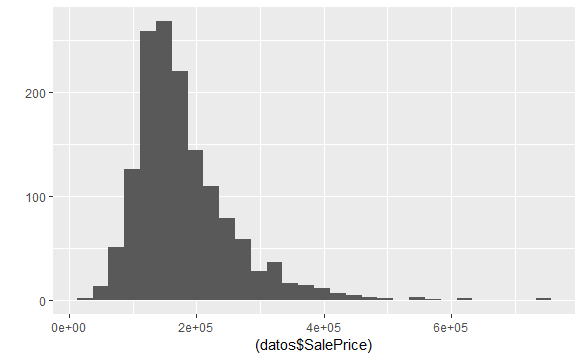

```r
qplot((datos$SalePrice))
```

**Nota: veremos más adelante más pasos de preprocesamiento para mejorar considerablemente el modelo que obtenemos abajo.**

### Regresión ridge

Separamos un conjunto de entrenamiento y uno de prueba (1/2 aproximadamente)

Notemos que en el siguiente codigo se debía corregir el -1 de los id’s pues esta columna ya había sido eliminada.

```r
set.seed(9911)
indices_entrena <- sample(1:nrow(x_datos), 700)
x_ent <- x_datos[indices_entrena,] # primera columna es de 1's, la quitamos
y_ent <- y[indices_entrena] / 1000 # miles de dólares
x_pr <- x_datos[-indices_entrena,]
y_pr <- y[-indices_entrena] / 1000 #miles de dólares
```

1. Utiliza la función glmnet para ajustar modelos lineales para valores de regularización. Utiliza la siguiente sucesión de valores $\lambda$ de regularización ridge:

```r
lambda <- exp(seq(-10, 10, 1))
lambda
```

```
 [1] 4.539993e-05 1.234098e-04 3.354626e-04 9.118820e-04 2.478752e-03
 [6] 6.737947e-03 1.831564e-02 4.978707e-02 1.353353e-01 3.678794e-01
[11] 1.000000e+00 2.718282e+00 7.389056e+00 2.008554e+01 5.459815e+01
[16] 1.484132e+02 4.034288e+02 1.096633e+03 2.980958e+03 8.103084e+03
[21] 2.202647e+04
```

```r
# completa los parámetros que faltan para ajustar los modelos:
mod_ridge <- glmnet(y = y_ent, x = x_ent, alpha = 0, family = "gaussian",
                lambda = lambda)
```

Grafica la traza de los coeficientes:

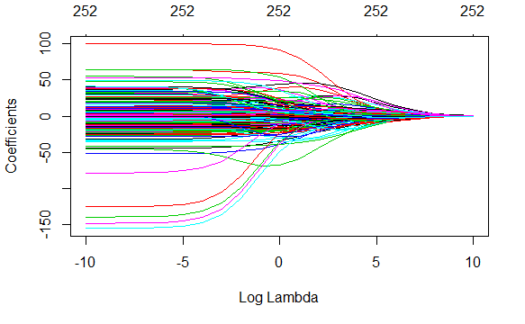

```r
plot(mod_ridge, xvar= "lambda")
```

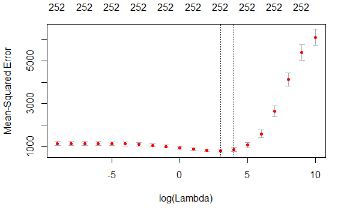

```r
# completa los parámetros que faltan:
cv_mod_1 <- cv.glmnet(y = y_ent , x = x_ent, alpha = 0, family = "gaussian",
                      lambda = lambda, nfolds = 10)
plot(cv_mod_1)
```

¿Qué valores de la regularización dan los errores más bajos (según la estimación de validación cruzada?)

3 y 4

3. Selecciona un modelo con baja regularización, con el valor óptimo según validación cruzada, y otro con mucha regularización (utiliza las lambdas mostradas abajo). Evalúa el error de predicción (raíz de error cuadrático media) según la muestra de prueba que separamos arriba:

```r
# rellena tres valores, uno con muy baja regularización , uno con regularización
#óptima según validación cruzada, y otro con demasiada regularización:
lambda_pred <- c(lambda[1] ,lambda[15] , lambda[20])
lambda_pred
```

```
[1] 4.539993e-05 5.459815e+01 8.103084e+03
```

Calcula errores de prueba

```r
preds_1 <- predict(mod_ridge, newx = x_pr, s = lambda_pred[1])
preds_2 <- predict(mod_ridge, newx = x_pr, s = lambda_pred[2])
preds_3 <- predict(mod_ridge, newx = x_pr, s = lambda_pred[3])
sqrt(mean((preds_1 - y_pr)^2))
```

```
[1] 41.21747
```

```r
sqrt(mean((preds_2 - y_pr)^2))
```

```
[1] 35.76028
```

```r
sqrt(mean((preds_3 - y_pr)^2))
```

```
[1] 70.10746
```

- ¿Qué modelo tiene el error más bajo de prueba? ¿Por qué esperarías esto?

El de lambda optimo, porque al estamos minimizando el error cuadratico + la regularización; para este caso usamos la lambda que mminimiza esta suma.

Grafica predicciones del modelo con menor error contra los valores observados

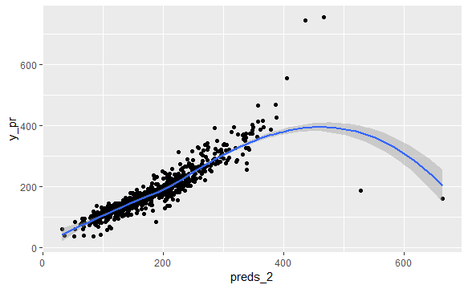

```r
mod_1_rid<-as.data.frame(cbind(y_pr,preds_3))
colnames(mod_1_rid)<-c("Valor real","Ajustado")
ggplot(mod_1_rid, aes(x=preds_2,y=y_pr))+geom_point()+
  geom_smooth()
```

```r
# Haz tu gráfica aquí
```

4. Compara los coeficientes del modelo menos regularizado con el de regularización óptima

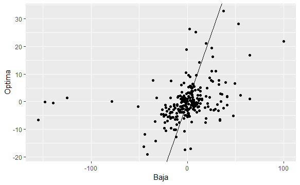

```r
coefs_reg_baja <- predict(mod_ridge,
                          s = lambda_pred[1], type= "coefficients")
coefs_reg_baja <- coefs_reg_baja[-1,1] # tomamos la primera columna y quitamos intercept
# rellena aquí
coefs_reg_opt <- predict(mod_ridge, s=lambda_pred[2],type = "coefficients")
coefs_reg_opt <- coefs_reg_opt[-1,1]
# ahora grafica estos coeficientes en una gráfica x-y:
coeficientes<-as.data.frame(cbind(coefs_reg_baja,coefs_reg_opt))
colnames(coeficientes)<-c("Baja","Optima")
ggplot(coeficientes, aes(x= Baja, y=Optima))+geom_point()+geom_abline()
```

- ¿Qué puedes decir acerca de la dispersión de los coeficientes del modelo con baja regularización en comparación al de regularización media? ¿Cuál es el rango de los coeficientes del modelo con baja regularización?

tienen una disperción más alta.

5. Compara algunos coeficientes de dos modelos, el de regularización baja con uno de regularización óptima según validación cruzada

Por ejemplo, compara los coeficientes relacionados con el garage (tipo, terminados, Calidad, Condición, coches y área):

```r
nombres <- rownames(as.data.frame(coefs_reg_baja))
coef_garage_baja <- coefs_reg_baja[str_detect(nombres, "Garage")]
coef_garage_baja
```

```
 GarageTypeAttchd GarageTypeBasment GarageTypeBuiltIn GarageTypeCarPort
       20.9964606        41.1308119        29.6561037        47.7401591
 GarageTypeDetchd      GarageTypeNA    GarageFinishNA   GarageFinishRFn
       21.3171391        -5.8818966        -2.2702349        -0.5284487
  GarageFinishUnf        GarageCars        GarageArea      GarageQualFa
        6.1559718         3.8107663         0.0241602      -155.0673314
     GarageQualGd      GarageQualNA      GarageQualPo      GarageQualTA
     -148.1304674        -2.9307091      -125.2736217      -139.2601103
     GarageCondFa      GarageCondGd      GarageCondNA      GarageCondPo
       18.4733358        29.2048136       -78.4777555         0.9713882
     GarageCondTA
       15.1194534
```

- ¿Qué efecto puede tener esta variable en tus predicciones? Considera que el tamaño de los coeficientes está en miles de dólares,

Tienen un rango muy amplio, incluso acercandose a la mediana, por lo que haría que nuestras estimaciones variaran mucho.

- ¿Cuál es el valor mediano de las casas en el conjunto de entrenamiento (y)? ¿Los efectos del inciso anterior te parecen razonables?
162. No ya que la presencia de alguna de estas variables llevaria a 0 la estimación.

```r
median(y_pr)
```

```
[1] 162.7
```

```r
min(coef_garage_baja)
```

```
[1] -155.0673
```

```r
max(coefs_reg_baja)
```

```
[1] 100.2451
```

Repite para regularización óptima según validación cruzada:

```r
coef_garage_opt
```

```
 GarageTypeAttchd GarageTypeBasment GarageTypeBuiltIn GarageTypeCarPort
      -0.66006246        1.72373417       11.14237504       -5.16886375
 GarageTypeDetchd      GarageTypeNA    GarageFinishNA   GarageFinishRFn
      -1.67386329        0.18227156        0.18361757       -2.66931558
  GarageFinishUnf        GarageCars        GarageArea      GarageQualFa
      -1.45367697        5.01581455        0.02302944       -6.57683496
     GarageQualGd      GarageQualNA      GarageQualPo      GarageQualTA
      -0.01748438        0.06811208        1.44521884       -0.46706535
     GarageCondFa      GarageCondGd      GarageCondNA      GarageCondPo
      -2.12476391       -2.76083121        0.01697561       -4.65155150
     GarageCondTA
       0.96080153
```

Observamos claramente que son más pequeños los coeficientes y tienen sentido vs la escala de nuestra variable respuesta.

```r
# calcula para los coeficientes del modelo más regularizado
coefs_reg_alta <- predict(mod_ridge, s=lambda_pred[3],type = "coefficients")
coefs_reg_alta <- coefs_reg_alta[-1,1]
coefs_reg_alta
```

```
        MSSubClass30         MSSubClass40         MSSubClass45
       -8.557357e-01         1.268887e-01        -5.669205e-01
        MSSubClass50         MSSubClass60         MSSubClass70
       -3.231970e-01         6.476526e-01        -1.039080e-01
        MSSubClass75         MSSubClass80         MSSubClass85
        1.961329e-01        -1.346319e-01        -3.414459e-01
        MSSubClass90        MSSubClass120        MSSubClass160
       -4.380312e-01         1.450474e-01        -4.218628e-01
       MSSubClass180        MSSubClass190           MSZoningFV
       -6.605740e-01        -5.489291e-01         1.404949e-01
          MSZoningRH           MSZoningRL           MSZoningRM
       -4.655982e-01         4.178495e-01        -5.241048e-01
             LotArea           StreetPave              AlleyNA
        1.836622e-05         5.270160e-01         3.705401e-01
           AlleyPave          LotShapeIR2          LotShapeIR3
       -1.386910e-01         6.550111e-01         6.385000e-01
         LotShapeReg       LandContourHLS       LandContourLow
       -4.653393e-01         6.218869e-01         3.695987e-01
      LandContourLvl      UtilitiesNoSeWa     LotConfigCulDSac
       -1.198231e-01         0.000000e+00         4.855645e-01
        LotConfigFR2         LotConfigFR3      LotConfigInside
        7.420426e-02         2.054707e-01        -1.564918e-01
        LandSlopeMod         LandSlopeSev  NeighborhoodBlueste
        2.675914e-01         4.250945e-01        -4.095973e-01
  NeighborhoodBrDale  NeighborhoodBrkSide  NeighborhoodClearCr
       -6.832086e-01        -4.782952e-01         2.667995e-01
 NeighborhoodCollgCr  NeighborhoodCrawfor  NeighborhoodEdwards
        1.406675e-01         4.386772e-01        -4.630912e-01
 NeighborhoodGilbert   NeighborhoodIDOTRR  NeighborhoodMeadowV
        4.065530e-02        -6.541638e-01        -7.833484e-01
 NeighborhoodMitchel    NeighborhoodNAmes  NeighborhoodNoRidge
       -3.184067e-01        -3.952284e-01         1.228580e+00
 NeighborhoodNPkVill  NeighborhoodNridgHt   NeighborhoodNWAmes
       -3.839086e-01         1.407473e+00         1.080055e-01
 NeighborhoodOldTown   NeighborhoodSawyer  NeighborhoodSawyerW
       -4.931246e-01        -3.984428e-01        -1.297592e-01
 NeighborhoodSomerst  NeighborhoodStoneBr    NeighborhoodSWISU
        2.717970e-01         1.553216e+00        -3.650615e-01
  NeighborhoodTimber  NeighborhoodVeenker      Condition1Feedr
        5.924872e-01         6.616060e-01        -3.173842e-01
```

[output cut: 123 more lines]

```
        5.310959e-04        -3.682375e-01        -3.223838e-01
           FenceMnWw              FenceNA        MiscFeatureNA
       -3.685245e-01         3.023190e-01         2.455568e-01
     MiscFeatureOthr      MiscFeatureShed      MiscFeatureTenC
       -7.473298e-01        -2.145827e-01         0.000000e+00
             MiscVal               YrSold          SaleTypeCon
       -2.735545e-05        -8.278145e-03         2.674642e-01
       SaleTypeConLD        SaleTypeConLI        SaleTypeConLw
       -4.420592e-01         1.598802e-01         1.357149e-01
         SaleTypeCWD          SaleTypeNew          SaleTypeOth
        3.916786e-01         1.019118e+00         0.000000e+00
          SaleTypeWD SaleConditionAdjLand  SaleConditionAlloca
       -5.624174e-01         0.000000e+00         1.336063e-02
 SaleConditionFamily  SaleConditionNormal SaleConditionPartial
       -1.687036e-02        -3.008037e-01         9.606503e-01
```

- ¿Qué efecto puede tener esta variable en tus predicciones? Considera que el tamaño de los coeficientes está en miles de dólares?

```r
min(coefs_reg_alta)
```

```
[1] -0.978174
```

```r
max(coefs_reg_alta)
```

```
[1] 1.553216
```

Son muy pequeños, lo que haría que difícilmente bajen o suban nuestras estimaciones, es decir el modelo es muy parecido a una constante.

- ¿Cuál es el valor mediano de las casas en el conjunto de entrenamiento (y)? ¿Los efectos del inciso anterior te parecen razonables?

```r
median(y_pr)
```

```
[1] 162.7
```

No, puesto que no movería a beta 1